# Lab08_ReinKatherine

2024-03-22

## Step 1: Data import and processing

```r
data <- read.csv("World_Development_Indicators.csv", na.strings = "#N/A")
CO2 = data[,"EN.ATM.CO2E.PC"]
```

## Step 2: Hypotheses generation

1. GDP per capita (current US$)

This one will most likely be positively correlated, as we discussed in class. More money means you are able to spend more on things that emit heavily.

2. Pump price for gasoline (US$ per liter)

This one will most likely be negatively correlated. The higher price of gas would mean people wouldn’t want to use a lot of gas meaning CO2 emissions will be lower.

3. Terrestrial and marine protected areas (% of total territorial area)

This one will most likely have a negative correlation. The more area that is protected means that factories or other big emitters can’t be on that land.

4. Population density (people per sq. km of land area)

This one will most likely be positively correlated. The more people the more carbon they can emit.

5. Average precipitation in depth (mm per year)

This one will most likely be positively correlated. Carbon emissions can cause a higher amounts of rainfall.

6. Arable land (hectares per person)

This one will most likely have a negative correlation. The more area that is used for farming means that factories or other big emitters can’t be on that land.

## Step 3: Exploratory data analysis

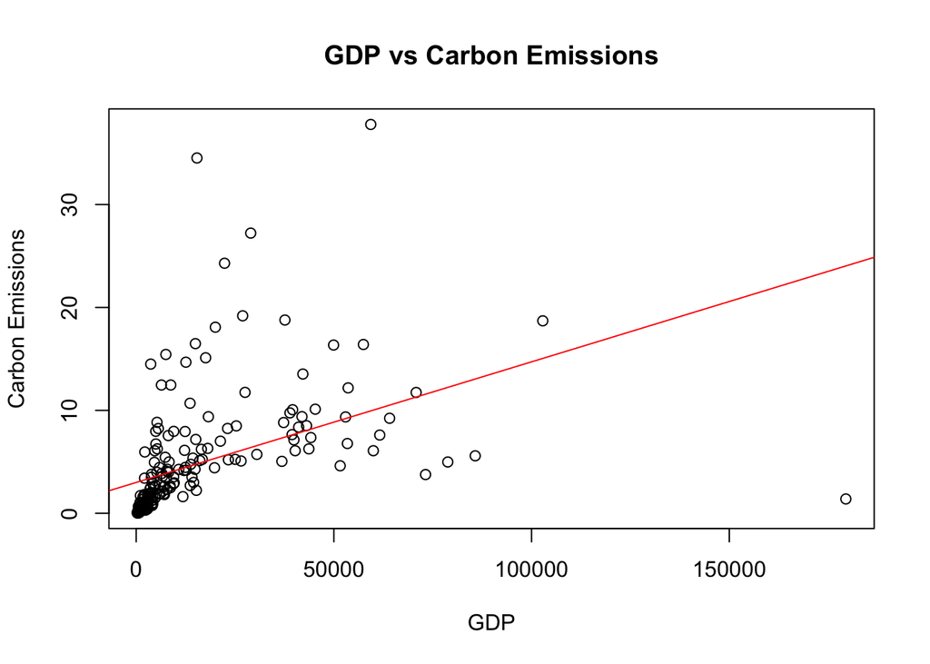

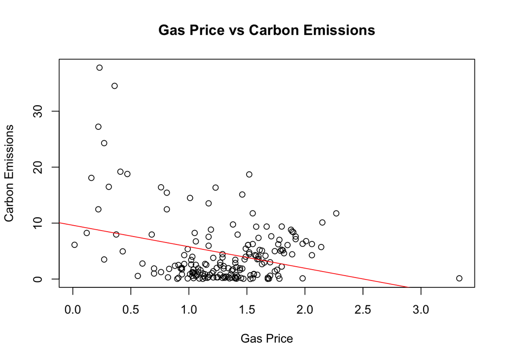

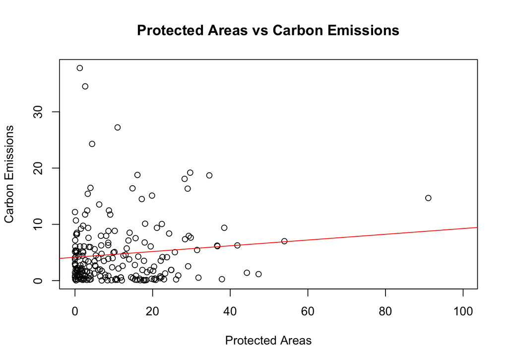

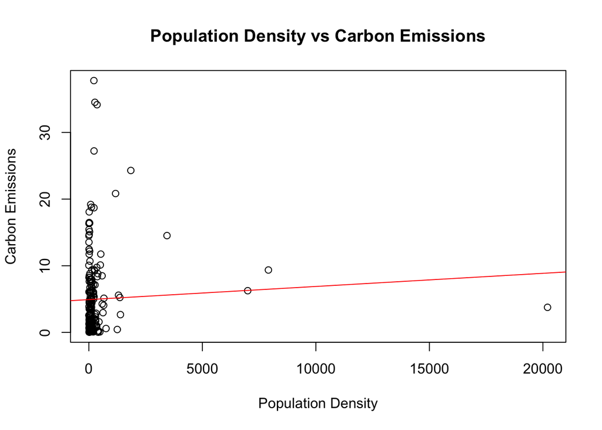

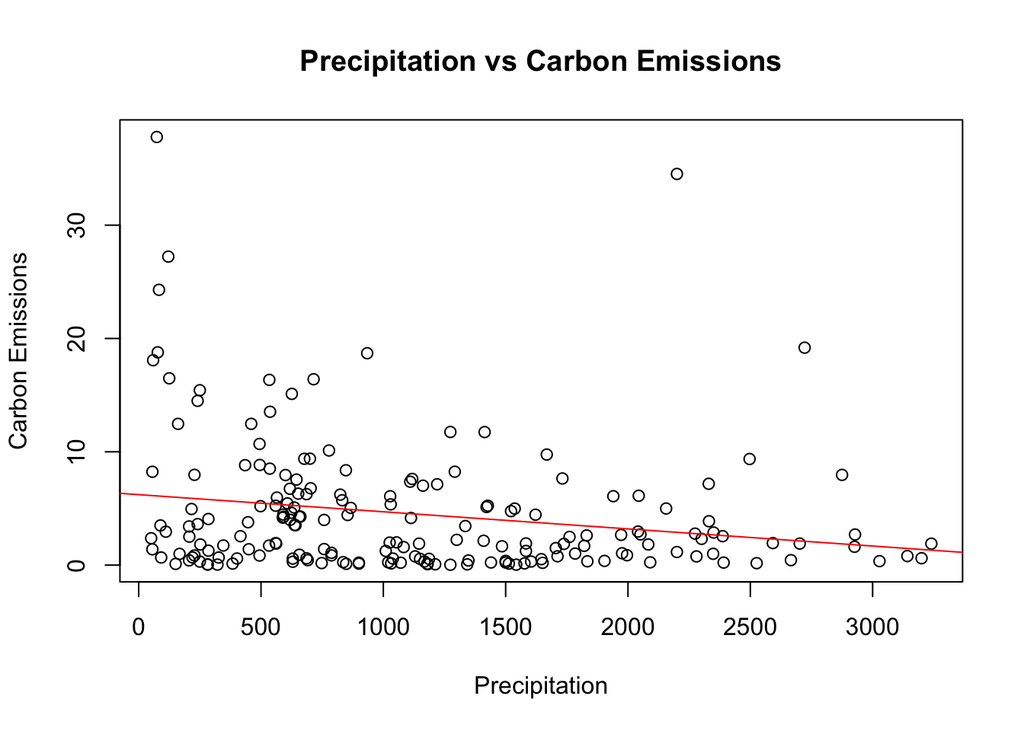

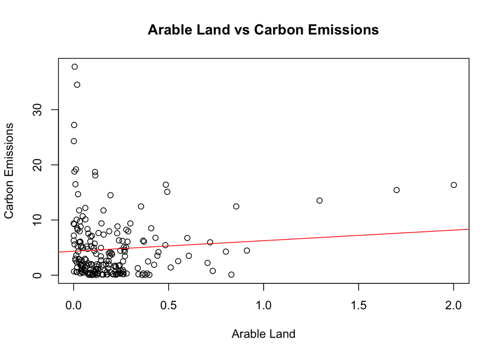

```r
# Create vectors of actual column names and what we want the variable names to be
xlabel_names = c("GDP","Gas Price","Protected Areas","Population Density",
                   "Precipitation", "Arable Land")
column_names = c("NY.GDP.PCAP.CD", "EP.PMP.SGAS.CD", "ER.PTD.TOTL.ZS", "EN.POP.DNST",
                  "AG.LND.PRCP.MM", "AG.LND.ARBL.HA.PC")

# Pull Out data from dataframe for each variable
GDP = data[,"NY.GDP.PCAP.CD"]
GasPrice = data[,"EP.PMP.SGAS.CD"]
ProtectedAreas = data[,"ER.PTD.TOTL.ZS"]
PopDens = data[,"EN.POP.DNST"]
Precipitation = data[,"AG.LND.PRCP.MM"]
ArableLand = data[,"AG.LND.ARBL.HA.PC"]


# Graph each variable
for (i in 1:6){
  xvariable = column_names[i]
  x_label = xlabel_names[i]

  plot(data[,xvariable], CO2, ylab = "Carbon Emissions", xlab = x_label, main =
         paste(x_label, "vs Carbon Emissions"))

  # Fit a linear regression model
  lm_model <- lm(CO2 ~ data[, xvariable])

  # Add the line of best fit to the plot
  abline(lm_model, col = "red")
}
```

```r
# Correlation Values/Regression Stats
print("***GDP***")
```

```
## [1] "***GDP***"
```

```r
cor(GDP, CO2, use = "complete.obs")
```

```
## [1] 0.4451325
```

```r
fit_GDP = lm(formula = EN.ATM.CO2E.PC ~ NY.GDP.PCAP.CD, data = data)
summary(fit_GDP)
```

```
##
## Call:
## lm(formula = EN.ATM.CO2E.PC ~ NY.GDP.PCAP.CD, data = data)
##
## Residuals:
##      Min       1Q   Median       3Q      Max
## -22.6442  -2.6535  -1.5143   0.5098  29.7196
##
## Coefficients:
##                 Estimate Std. Error t value Pr(>|t|)
## (Intercept)    2.9977563  0.4448390   6.739 1.72e-10 ***
## NY.GDP.PCAP.CD 0.0001172  0.0000168   6.977 4.47e-11 ***
## ---
## Signif. codes:  0 '***' 0.001 '**' 0.01 '*' 0.05 '.' 0.1 ' ' 1
##
## Residual standard error: 5.248 on 197 degrees of freedom
##   (18 observations deleted due to missingness)
## Multiple R-squared:  0.1981, Adjusted R-squared:  0.1941
## F-statistic: 48.68 on 1 and 197 DF,  p-value: 4.475e-11
```

```r
print("***Gas Price***")
```

```
## [1] "***Gas Price***"
```

```r
cor(GasPrice, CO2, use = "complete.obs")
```

```
## [1] -0.3033878
```

```r
fit_GasPrice = lm(formula = EN.ATM.CO2E.PC ~ EP.PMP.SGAS.CD, data = data)
summary(fit_GasPrice)
```

```
##
## Call:
## lm(formula = EN.ATM.CO2E.PC ~ EP.PMP.SGAS.CD, data = data)
##
## Residuals:
##    Min     1Q Median     3Q    Max
## -6.915 -4.083 -2.149  2.491 29.042
##
## Coefficients:
##                Estimate Std. Error t value Pr(>|t|)
## (Intercept)      9.6207     1.2446   7.730 7.76e-13 ***
## EP.PMP.SGAS.CD  -3.8381     0.9061  -4.236 3.65e-05 ***
## ---
## Signif. codes:  0 '***' 0.001 '**' 0.01 '*' 0.05 '.' 0.1 ' ' 1
##
## Residual standard error: 5.713 on 177 degrees of freedom
##   (38 observations deleted due to missingness)
## Multiple R-squared:  0.09204,    Adjusted R-squared:  0.08691
## F-statistic: 17.94 on 1 and 177 DF,  p-value: 3.654e-05
```

```r
print("***Protected Areas***")
```

```
## [1] "***Protected Areas***"
```

```r
cor(ProtectedAreas, CO2, use = "complete.obs")
```

```
## [1] 0.1085938
```

```r
fit_ProtectedAreas = lm(formula = EN.ATM.CO2E.PC ~ ER.PTD.TOTL.ZS, data = data)
summary(fit_ProtectedAreas)
```

```
##
## Call:
## lm(formula = EN.ATM.CO2E.PC ~ ER.PTD.TOTL.ZS, data = data)
##
## Residuals:
##    Min     1Q Median     3Q    Max
## -5.836 -3.808 -1.742  1.718 33.566
##
## Coefficients:
##                Estimate Std. Error t value Pr(>|t|)
## (Intercept)     4.15084    0.55079   7.536 1.67e-12 ***
## ER.PTD.TOTL.ZS  0.05118    0.03321   1.541    0.125
## ---
## Signif. codes:  0 '***' 0.001 '**' 0.01 '*' 0.05 '.' 0.1 ' ' 1
##
## Residual standard error: 5.793 on 199 degrees of freedom
##   (16 observations deleted due to missingness)
## Multiple R-squared:  0.01179,    Adjusted R-squared:  0.006827
## F-statistic: 2.375 on 1 and 199 DF,  p-value: 0.1249
```

```r
print("***Population Density***")
```

```
## [1] "***Population Density***"
```

```r
cor(PopDens, CO2, use = "complete.obs")
```

```
## [1] 0.05072314
```

```r
fit_PopDens = lm(formula = EN.ATM.CO2E.PC ~ EN.POP.DNST, data = data)
summary(fit_PopDens)
```

```
##
## Call:
## lm(formula = EN.ATM.CO2E.PC ~ EN.POP.DNST, data = data)
##
## Residuals:
##    Min     1Q Median     3Q    Max
## -5.150 -4.177 -2.251  1.476 32.813
##
## Coefficients:
##              Estimate Std. Error t value Pr(>|t|)
## (Intercept) 4.9237531  0.4495338  10.953   <2e-16 ***
## EN.POP.DNST 0.0001975  0.0002736   0.722    0.471
## ---
## Signif. codes:  0 '***' 0.001 '**' 0.01 '*' 0.05 '.' 0.1 ' ' 1
##
## Residual standard error: 6.27 on 202 degrees of freedom
##   (13 observations deleted due to missingness)
## Multiple R-squared:  0.002573,   Adjusted R-squared:  -0.002365
## F-statistic: 0.5211 on 1 and 202 DF,  p-value: 0.4712
```

```r
print("***Precipiation***")
```

```
## [1] "***Precipiation***"
```

```r
cor(Precipitation, CO2, use = "complete.obs")
```

```
## [1] -0.2022101
```

```r
fit_Precipitation = lm(formula = EN.ATM.CO2E.PC ~ AG.LND.PRCP.MM, data = data)
summary(fit_Precipitation)
```

```
##
## Call:
## lm(formula = EN.ATM.CO2E.PC ~ AG.LND.PRCP.MM, data = data)
##
## Residuals:
##    Min     1Q Median     3Q    Max
## -5.888 -3.774 -1.673  1.245 31.669
##
## Coefficients:
##                  Estimate Std. Error t value Pr(>|t|)
## (Intercept)     6.2226793  0.7329351   8.490 6.29e-15 ***
## AG.LND.PRCP.MM -0.0015128  0.0005358  -2.824  0.00526 **
## ---
## Signif. codes:  0 '***' 0.001 '**' 0.01 '*' 0.05 '.' 0.1 ' ' 1
##
## Residual standard error: 5.788 on 187 degrees of freedom
##   (28 observations deleted due to missingness)
## Multiple R-squared:  0.04089,    Adjusted R-squared:  0.03576
## F-statistic: 7.972 on 1 and 187 DF,  p-value: 0.005265
```

```r
print("***Arable Land***")
```

```
## [1] "***Arable Land***"
```

```r
cor(ArableLand, CO2, use = "complete.obs")
```

```
## [1] 0.08372951
```

```r
fit_ArableLand = lm(formula = EN.ATM.CO2E.PC ~ AG.LND.ARBL.HA.PC, data = data)
summary(fit_ArableLand)
```

```
##
## Call:
## lm(formula = EN.ATM.CO2E.PC ~ AG.LND.ARBL.HA.PC, data = data)
##
## Residuals:
##    Min     1Q Median     3Q    Max
## -5.828 -3.817 -1.987  1.610 33.428
##
## Coefficients:
##                   Estimate Std. Error t value Pr(>|t|)
## (Intercept)         4.3418     0.5287   8.212 2.83e-14 ***
## AG.LND.ARBL.HA.PC   1.9178     1.6262   1.179     0.24
## ---
## Signif. codes:  0 '***' 0.001 '**' 0.01 '*' 0.05 '.' 0.1 ' ' 1
##
## Residual standard error: 5.835 on 197 degrees of freedom
##   (18 observations deleted due to missingness)
## Multiple R-squared:  0.007011,   Adjusted R-squared:  0.00197
## F-statistic: 1.391 on 1 and 197 DF,  p-value: 0.2397
```

GDP: Yes, I said that they would be positively correlated and they were. Gas Price: Yes, I said that they would be negatively correlated and they were. Protected Areas: No, I said negative and there’s a very small positive correlation. Pop Dens: Yes, I said positive and there’s a very small positive correlation. Precipitation: No, I said positive but it ended up being negative. Arable Land: No, I said negative and there’s a very small positive correlation.